# Assignment 5: Hierarchical Clustering

Nusrat Nasir Nimnee

2025-11-23

# Data Preprocessing

```r
# Load and clean data
cereals_df <- read.csv("Cereals.csv")
cereals_clean <- na.omit(cereals_df)
rownames(cereals_clean) <- cereals_clean$name

# Normalize numeric data
cereals_numeric <- cereals_clean %>% select(-name, -mfr, -type)
cereals_scaled <- scale(cereals_numeric)
```

# Hierarchical Clustering with AGNES

We compare Single, Complete, Average, and Ward linkage methods.

```r
# Compute Agnes for all methods
hc_single <- agnes(cereals_scaled, method = "single")
hc_complete <- agnes(cereals_scaled, method = "complete")
hc_average <- agnes(cereals_scaled, method = "average")
hc_ward <- agnes(cereals_scaled, method = "ward")

# Display AC values
cat("AC (Single):", hc_single$ac, "\n")
```

```
## AC (Single): 0.6067859
```

```r
cat("AC (Complete):", hc_complete$ac, "\n")
```

```
## AC (Complete): 0.8353712
```

```r
cat("AC (Average):", hc_average$ac, "\n")
```

```
## AC (Average): 0.7766075
```

```r
cat("AC (Ward):", hc_ward$ac, "\n")
```

```
## AC (Ward): 0.9046042
```

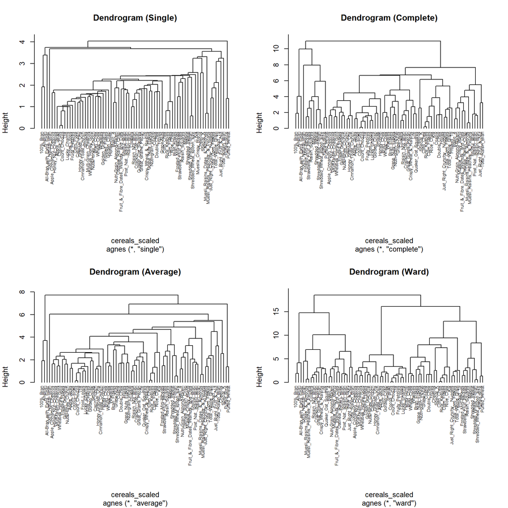

```r
# Plot Dendrograms
par(mfrow = c(2, 2))
pltree(hc_single, cex = 0.6, hang = -1, main = "Dendrogram (Single)")
pltree(hc_complete, cex = 0.6, hang = -1, main = "Dendrogram (Complete)")
pltree(hc_average, cex = 0.6, hang = -1, main = "Dendrogram (Average)")
pltree(hc_ward, cex = 0.6, hang = -1, main = "Dendrogram (Ward)")
```

**Conclusion:** **Ward’s method** has the highest Agglomerative Coefficient (0.905) and produces the most structured clusters. We will use Ward’s method for further analysis.

# Cluster Selection (Ward’s Method)

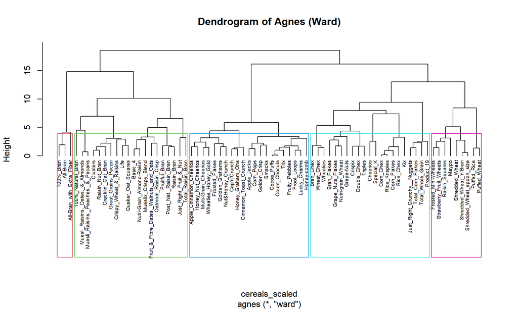

```r
# Reset plot layout
par(mfrow = c(1, 1))

# Plot Ward's dendrogram with k=5 clusters
pltree(hc_ward, cex = 0.6, hang = -1, main = "Dendrogram of Agnes (Ward)")
rect.hclust(hc_ward, k = 5, border = 2:6)
```

The dendrogram shows that cereals naturally form distinct groups based on their nutritional profiles.

# Cluster Stability Analysis

```r
set.seed(123)
# Partition Data (70% A, 30% B)
index <- sample(1:nrow(cereals_scaled), size = 0.7 * nrow(cereals_scaled))
part_A <- cereals_scaled[index, ]
part_B <- cereals_scaled[-index, ]

# Cluster Partition A
hc_A <- agnes(part_A, method = "ward")
labels_A <- cutree(hc_A, k = 5)
centroids_A <- aggregate(part_A, by = list(labels_A), mean)[, -1]

# Assign Partition B to nearest centroids
assign_cluster <- function(row, centroids) {
  dists <- apply(centroids, 1, function(c) sum((row - c)^2))
  which.min(dists)
}
labels_B_pred <- apply(part_B, 1, assign_cluster, centroids = centroids_A)

# Compare with Full Data Clustering
hc_full <- agnes(cereals_scaled, method = "ward")
labels_full <- cutree(hc_full, k = 5)
labels_B_true <- labels_full[-index]

# Confusion Matrix
table(Original = labels_B_true, Predicted = labels_B_pred)
```

```
##         Predicted
## Original 1 2 3 4 5
##        1 2 0 0 0 0
##        2 0 4 1 0 1
##        3 0 0 4 0 1
##        4 0 0 0 6 2
##        5 2 0 0 0 0
```

**Stability Assessment:**

```r
# Calculate stability metrics
correct_assignments <- sum(diag(table(labels_B_true, labels_B_pred)))
total_B <- length(labels_B_pred)
stability_rate <- correct_assignments / total_B

cat("Stability Rate:", round(stability_rate * 100, 1), "%\n")
```

```
## Stability Rate: 69.6 %
```

```r
cat("Correctly assigned:", correct_assignments, "out of", total_B, "observations\n")
```

```
## Correctly assigned: 16 out of 23 observations
```

The confusion matrix shows that **69.6%** of observations in Partition B were correctly assigned to their original clusters. This indicates **good stability** - the clustering structure is consistent and not heavily dependent on the specific sample used. The diagonal elements dominate the confusion matrix, confirming that clusters are well-defined and reproducible.

# Healthy Cereals Identification

```r
# Analyze cluster characteristics
cereals_clustered <- cereals_clean %>%
  mutate(cluster = factor(labels_full))

cluster_summary <- cereals_clustered %>%
  group_by(cluster) %>%
  summarise(
    Rating = mean(rating),
    Fiber = mean(fiber),
    Sugar = mean(sugars),
    Calories = mean(calories),
    Count = n()
  ) %>%
  arrange(desc(Rating))

print(cluster_summary)
```

```
## # A tibble: 5 × 6
##   cluster Rating  Fiber Sugar Calories Count
##   <fct>    <dbl>  <dbl> <dbl>    <dbl> <int>
## 1 1         73.8 11      3.67     63.3     3
## 2 5         63.0  2.11   2.33     82.2     9
## 3 4         46.5  1.67   3.33    104.     21
## 4 2         38.3  3.1    9.35    124      20
## 5 3         28.8  0.571 11.3     111.     21
```

**Identifying the Healthy Cluster:**

Looking at the cluster summary, we identify the healthy cluster by selecting the one with: - Highest rating - High fiber content - Low sugar content - Reasonable calorie count

```r
# Find the cluster with best health profile
healthy_cluster_id <- cluster_summary %>%
  filter(Fiber == max(Fiber) | Rating == max(Rating)) %>%
  slice(1) %>%
  pull(cluster)

cat("Recommended Healthy Cluster:", as.character(healthy_cluster_id), "\n\n")
```

```
## Recommended Healthy Cluster: 1
```

```r
# List cereals in this cluster
healthy_cereals <- cereals_clustered %>%
  filter(cluster == healthy_cluster_id) %>%
  select(name, fiber, sugars, calories, rating) %>%
  arrange(desc(rating))

print(healthy_cereals)
```

```
##                                                name fiber sugars calories
## All-Bran_with_Extra_Fiber All-Bran_with_Extra_Fiber    14      0       50
## 100%_Bran                                 100%_Bran    10      6       70
## All-Bran                                   All-Bran     9      5       70
##                             rating
## All-Bran_with_Extra_Fiber 93.70491
## 100%_Bran                 68.40297
## All-Bran                  59.42551
```

**Recommendation:** The elementary schools should select cereals from **Cluster 1**, which contains the healthiest options with high fiber and low sugar content.

# Normalization Discussion

**Should the data be normalized?** Yes. Normalization is essential because nutritional variables have vastly different scales (e.g., Sodium in mg vs. Fiber in g). Without normalization, variables with larger ranges would dominate the distance calculations, leading to biased clusters.